# Project 3 - Main_Baseline

Chengliang Tang, Tian Zheng, Group 10: Peilu Zhang

```r
if(!require("EBImage")){
  source("https://bioconductor.org/biocLite.R")
  biocLite("EBImage")
}

if(!require("gbm")){
  install.packages("gbm")
}

library("EBImage")
library("gbm")
```

### Step 0: specify directories.

Set the working directory to the image folder. Specify the training and the testing set. For data without an independent test/validation set, you need to create your own testing data by random subsampling. In order to obain reproducible results, set.seed() whenever randomization is used.

```r
set.seed(2018)
setwd("~/Documents/2018-fall-study/5243/proj3")
# here replace it with your own path or manually set it in RStudio to where this rmd file is located.
# use relative path for reproducibility
```

Provide directories for training images. Low-resolution (LR) image set and High-resolution (HR) image set will be in different subfolders.

```r
train_dir <- "~/Documents/2018-fall-study/5243/proj3/data/train_set/" # This will be modified for different data sets.
train_LR_dir <- paste(train_dir, "LR/", sep="")
train_HR_dir <- paste(train_dir, "HR/", sep="")
train_label_path <- paste(train_dir, "label.csv", sep="")
```

### Step 1: set up controls for evaluation experiments.

In this chunk, we have a set of controls for the evaluation experiments.

- (T/F) cross-validation on the training set
- (number) K, the number of CV folds
- (T/F) process features for training set
- (T/F) run evaluation on an independent test set
- (T/F) process features for test set

```r
run.cv=TRUE # run cross-validation on the training set
K <- 10  # number of CV folds
run.feature.train=TRUE # process features for training set
run.test=TRUE # run evaluation on an independent test set
run.feature.test=TRUE # process features for test set
```

Using cross-validation or independent test set evaluation, we compare the performance of models with different specifications. In this example, we use GBM with different `depth`. In the following chunk, we list, in a vector, setups (in this case, `depth`) corresponding to models that we will compare. In your project, you might compare very different classifiers. You can assign them numerical IDs and labels specific to your project.

```r
model_values <- seq(3, 11, 2)
model_labels = paste("GBM with depth =", model_values)
```

### Step 2: import training images class labels.

We provide extra information of image label: car (0), flower (1), market (2). These labels are not necessary for your model.

```r
extra_label <- read.csv(train_label_path, colClasses=c("NULL", NA, NA))
```

### Step 3: construct features and responses

`feature.R` should be the wrapper for all your feature engineering functions and options. The function `feature( )` should have options that correspond to different scenarios for your project and produces an R object that contains features and responses that are required by all the models you are going to evaluate later. + `feature.R` + Input: a path for low-resolution images. + Input: a path for high-resolution images. + Output: an RData file that contains extracted features and corresponding responses

```r
source("~/Documents/2018-fall-study/5243/proj3/lib/feature_baseline.R")
tm_feature_train <- NA
if(run.feature.train){
  tm_feature_train <- system.time(dat_train <- feature(train_LR_dir, train_HR_dir))
  feat_train <- dat_train$feature
  label_train <- dat_train$label
}
save(dat_train, file="~/Documents/2018-fall-study/5243/proj3/output/feature_train_baseline.RData")
tm_feature_train
```

```
   user  system elapsed
 99.291  64.246 172.121
```

### Step 4: Train a regression model with training features and responses

Call the train model and test model from library.

`train.R` and `test.R` should be wrappers for all your model training steps and your classification/prediction steps. + `train.R` + Input: a path that points to the training set features and responses. + Output: an RData file that contains trained classifiers in the forms of R objects: models/settings/links to external trained configurations. + `test.R` + Input: a path that points to the test set features. + Input: an R object that contains a trained classifier. + Output: an R object of response predictions on the test set. If there are multiple classifiers under evaluation, there should be multiple sets of label predictions.

```r
source("~/Documents/2018-fall-study/5243/proj3/lib/train_baseline.R")
source("~/Documents/2018-fall-study/5243/proj3/lib/test_baseline.R")
```

#### Model selection with cross-validation

- Do model selection by choosing among different values of training model parameters, that is, the interaction depth for GBM in this example.

```r
source("~/Documents/2018-fall-study/5243/proj3/lib/cross_validation_baseline.R")

if(run.cv){
  err_cv <- array(dim=c(length(model_values), 2))
  for(k in 1:length(model_values)){
    cat("k=", k, "\n")
    err_cv[k,] <- cv.function(feat_train, label_train, model_values[k], K)
  }
  save(err_cv, file="../output/err_cv_baseline.RData")
}
err_cv
```

[output not shown]

Visualize cross-validation results.

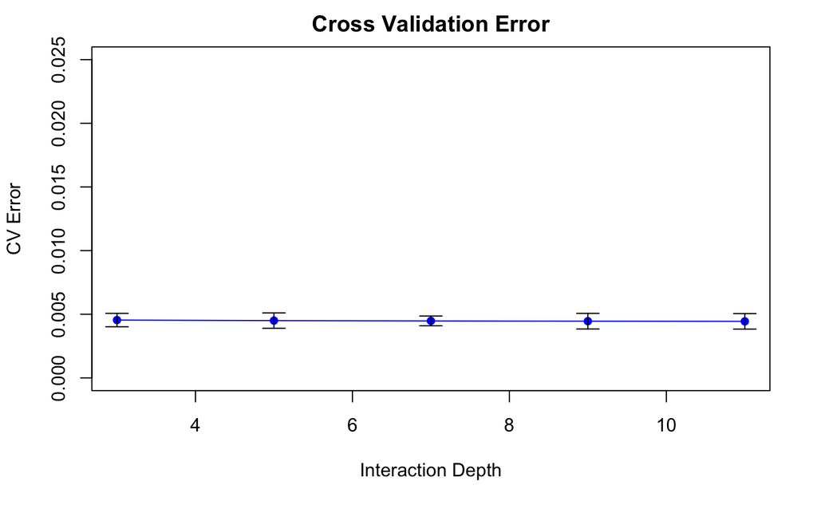

```r
if(run.cv){
  load("~/Documents/2018-fall-study/5243/proj3/output/err_cv_baseline.RData")
  plot(model_values, err_cv[,1], xlab="Interaction Depth", ylab="CV Error",
       main="Cross Validation Error", type="n", ylim=c(0, 0.025))
  points(model_values, err_cv[,1], col="blue", pch=16)
  lines(model_values, err_cv[,1], col="blue")
  arrows(model_values, err_cv[,1]-err_cv[,2], model_values, err_cv[,1]+err_cv[,2],
        length=0.1, angle=90, code=3)
}
```

- Choose the “best”" parameter value

```r
model_best=model_values[1]
if(run.cv){
  model_best <- model_values[which.min(err_cv[,1])]
}
par_best <- list(depth=model_best)
par_best
```

```
$depth
[1] 11
```

For baseline we only use depth = 1

```r
par_best1= list(depth = 1)
```

```r
tm_train=NA
tm_train <- system.time(fit_train <- train(feat_train, label_train, par_best1))
save(fit_train, file="~/Documents/2018-fall-study/5243/proj3/output/fit_train_baseline.RData")
```

### Step 5: Super-resolution for test images

Feed the final training model with the completely holdout testing data. + `superResolution.R` + Input: a path that points to the folder of low-resolution test images. + Input: a path that points to the folder (empty) of high-resolution test images. + Input: an R object that contains tuned predictors. + Output: construct high-resolution versions for each low-resolution test image.

```r
source("~/Documents/2018-fall-study/5243/proj3/lib/superResolution_baseline.R")
test_dir <- "~/Documents/2018-fall-study/5243/proj3/data/test_set/" # This will be modified for different data sets.
test_LR_dir <- paste(test_dir, "LR/", sep="")
test_HR_dir <- paste(test_dir, "HR/", sep="")
tm_test=NA
if(run.test){
  load(file="~/Documents/2018-fall-study/5243/proj3/output/fit_train.RData")
  tm_test <- system.time(superResolution(test_LR_dir, test_HR_dir, fit_train))
}
```

### Summarize Running Time

Prediction performance matters, so does the running times for constructing features and for training the model, especially when the computation resource is limited.

```r
cat("Time for constructing training features=", tm_feature_train[1], "s \n")
```

```
Time for constructing training features= 99.291 s
```

```r
#cat("Time for constructing testing features=", tm_feature_test[1], "s \n")
cat("Time for training model=", tm_train[1], "s \n")
```

```
Time for training model= 1750.044 s
```

```r
cat("Time for super-resolution=", tm_test[1], "s \n")
```

```
Time for super-resolution= 69.081 s
```

### PSNR for our training data

```r
#calculates MSE
mse <- function(x_hat,x) {
  mean((x_hat-x)^2)
}

#calculate PSNR
psnr <- function(x_hat,x) {
  10 * log10(1/mse(x_hat,x))
}


calculate_psnr <- function(pred_dir, true_dir){
  library(OpenImageR)
  n_pred <- length(list.files(pred_dir))
  n_true <- length(list.files(true_dir))
  if(n_pred != n_true){
    stop("input lists must be same length")
  }

  list <- matrix(0, nrow = (n_pred + 1), ncol = 1)
  name <- c("Total")
  for (i in 1:n_pred){
    imgPred <- OpenImageR::readImage(paste0(test_HR_dir,  "img_", sprintf("%04d", 1), ".jpg"))
    imgTrue <- OpenImageR::readImage(paste0(true_dir,  "img_", sprintf("%04d", i), ".jpg"))

    list[i+1,] <- psnr(imgPred, imgTrue)
    name <- c(name, paste0("img_", sprintf("%04d", i)))
  }
  list[1,] <- mean(list[-1,1])
  row.names(list) <- name
  colnames(list) <- substring(pred_dir,18)
  return(list)
}

#install.packages("OpenImageR")
library(OpenImageR)
# set directory
HR_dir1 = "~/Documents/2018-fall-study/5243/proj3/data/train_set2/HR/"
train_HR_dir1 <- paste(HR_dir1, sep = "")
HR_dir_test = "~/Documents/2018-fall-study/5243/proj3/data/test_set2/HR/"
test_HR_dir = paste(HR_dir_test, sep = "")
# psnr for baseline
psnr_baseline = calculate_psnr(test_HR_dir,train_HR_dir1)
psnr_baseline
```

[output not shown]